# Predicting Hazardous Near-Earth Objects

Ryan Horsey, Scott Engstrom, Pablo Leguizamo, Shashank Koneru

2026-04-14

## Research Topic

**Predicting Hazardous Near-Earth Objects (NEOs)**

## Team Members

- Ryan Horsey
- Scott Engstrom
- Pablo Leguizamo
- Shashank Koneru

## Data Description

### Dataset

We are using data from **NASA’s NeoWs (Near Earth Object Web Service)** API, which provides detailed information on near-Earth asteroids tracked by NASA’s Jet Propulsion Laboratory.

- **API Endpoint:** `https://api.nasa.gov/neo/rest/v1/feed`
- **API Documentation:** https://api.nasa.gov
- **Fallback / Mirror Dataset (Kaggle):** https://www.kaggle.com/datasets/sameepvani/nasa-nearest-earth-objects

The dataset contains records on thousands of near-Earth objects with variables including estimated diameter, relative velocity, miss distance from Earth, orbital body, and a binary label indicating whether the object is classified as potentially hazardous.

```r
library(httr)
library(jsonlite)
library(dplyr)
library(tidyr)
library(ggplot2)

# Load API key from environment variable (set in .Renviron as NASA_KEY=your_key), use "DEMO_KEY" if you have none.
# api_key <- Sys.getenv("NASA_KEY")
api_key <- "DEMO_KEY"

# Function to pull one week of NEO data from the API
fetch_neo_week <- function(start_date, end_date, key) {
  url <- paste0(
    "https://api.nasa.gov/neo/rest/v1/feed",
    "?start_date=", start_date,
    "&end_date=", end_date,
    "&api_key=", key
  )
  response <- GET(url)

  if (status_code(response) != 200) {
    warning(paste("API call failed for range:", start_date, "to", end_date))
    return(NULL)
  }

  data <- fromJSON(content(response, as = "text"), flatten = TRUE)
  neo_list <- data$near_earth_objects
  bind_rows(neo_list)
}

# Pull several weeks of data and combine
date_ranges <- list(
  c("2023-01-01", "2023-01-07"),
  c("2023-02-01", "2023-02-07"),
  c("2023-03-01", "2023-03-07"),
  c("2023-04-01", "2023-04-07"),
  c("2023-05-01", "2023-05-07"),
  c("2023-06-01", "2023-06-07")
)

neo_raw <- bind_rows(lapply(date_ranges, function(r) {
  Sys.sleep(1)  # be polite to the API
  fetch_neo_week(r[1], r[2], api_key)
}))
```

### Initial Data Cleaning Steps

The raw API response is nested JSON, requiring several cleaning steps:

```r
# Unnest the close_approach_data list-column
neo_df <- neo_raw %>%
  unnest(cols = close_approach_data) %>%
  select(
    id,
    name,
    is_potentially_hazardous_asteroid,
    estimated_diameter.kilometers.estimated_diameter_min,
    estimated_diameter.kilometers.estimated_diameter_max,
    relative_velocity.kilometers_per_second,
    miss_distance.kilometers,
    orbiting_body,
    close_approach_date
  ) %>%
  rename(
    hazardous       = is_potentially_hazardous_asteroid,
    diam_min_km     = estimated_diameter.kilometers.estimated_diameter_min,
    diam_max_km     = estimated_diameter.kilometers.estimated_diameter_max,
    velocity_kps    = relative_velocity.kilometers_per_second,
    miss_dist_km    = miss_distance.kilometers,
    approach_date   = close_approach_date
  ) %>%
  mutate(
    hazardous    = as.factor(hazardous),
    velocity_kps = as.numeric(velocity_kps),
    miss_dist_km = as.numeric(miss_dist_km),
    diam_avg_km  = (diam_min_km + diam_max_km) / 2,
    approach_date = as.Date(approach_date)
  ) %>%
  # Remove duplicate NEO entries (same object, multiple close approach dates)
  distinct(id, approach_date, .keep_all = TRUE)
```

**Anticipated cleaning steps include:**

- Unnesting the nested `close_approach_data` list-column
- Converting character columns (velocity, miss distance) to numeric
- Engineering a mean diameter variable from the min/max estimates
- Removing duplicate entries for the same NEO across multiple approach dates
- Handling any missing values in diameter or velocity fields
- Checking for class imbalance in the `hazardous` target variable

## Basic / Marginal Summaries

```r
# Dimensions
cat("Rows:", nrow(neo_df), "\n")
```

```
## Rows: 495
```

```r
cat("Columns:", ncol(neo_df), "\n")
```

```
## Columns: 10
```

```r
# Summary statistics
summary(neo_df[, c("diam_avg_km", "velocity_kps", "miss_dist_km")])
```

```
##   diam_avg_km        velocity_kps     miss_dist_km
##  Min.   :0.001966   Min.   : 1.416   Min.   :  675810
##  1st Qu.:0.024977   1st Qu.: 7.724   1st Qu.:11457244
##  Median :0.049607   Median :11.156   Median :27322012
##  Mean   :0.113726   Mean   :12.384   Mean   :30946575
##  3rd Qu.:0.129283   3rd Qu.:16.200   3rd Qu.:48119067
##  Max.   :1.335189   Max.   :33.987   Max.   :74174911
```

```r
# Class balance of target variable
table(neo_df$hazardous)
```

```
##
## FALSE  TRUE
##   463    32
```

```r
prop.table(table(neo_df$hazardous))
```

```
##
##      FALSE       TRUE
## 0.93535354 0.06464646
```

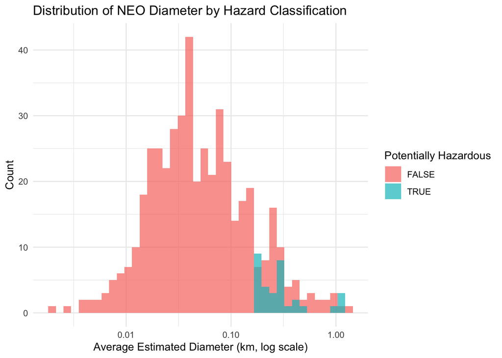

```r
# Distribution of average diameter by hazard classification
ggplot(neo_df, aes(x = diam_avg_km, fill = hazardous)) +
  geom_histogram(bins = 40, alpha = 0.7, position = "identity") +
  scale_x_log10() +
  labs(
    title = "Distribution of NEO Diameter by Hazard Classification",
    x = "Average Estimated Diameter (km, log scale)",
    y = "Count",
    fill = "Potentially Hazardous"
  ) +
  theme_minimal()
```

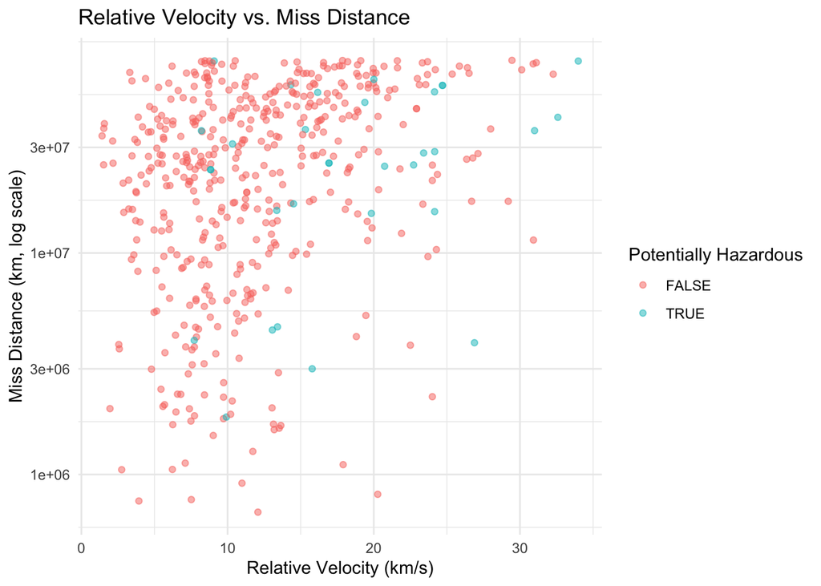

```r
# Velocity vs. Miss Distance, colored by hazard status
ggplot(neo_df, aes(x = velocity_kps, y = miss_dist_km, color = hazardous)) +
  geom_point(alpha = 0.5) +
  scale_y_log10() +
  labs(
    title = "Relative Velocity vs. Miss Distance",
    x = "Relative Velocity (km/s)",
    y = "Miss Distance (km, log scale)",
    color = "Potentially Hazardous"
  ) +
  theme_minimal()
```

## Project Idea / Research Questions

### What are we trying to investigate?

We aim to investigate what physical and orbital characteristics of near-Earth objects are most predictive of whether NASA classifies them as **potentially hazardous**. Specifically:

- Does asteroid **size** (estimated diameter) significantly predict hazard classification?
- Does **relative velocity** at closest approach differ between hazardous and non-hazardous NEOs?
- Does **miss distance** from Earth contribute most to the classification, or is it diameter?
- Can we build a model that accurately predicts hazard status from available features?

### Analyses and Visualizations We Expect to Use

**Visualizations:**

- Histograms and density plots of diameter, velocity, and miss distance split by hazard class
- Scatter plot of velocity vs. miss distance colored by hazard classification
- Correlation heatmap of numeric predictors
- Variable importance plot from the final model

**Statistical Analyses:**

- Logistic regression to model `hazardous` (binary) as a function of diameter, velocity, and miss distance
- Classification tree or random forest for comparison and variable importance
- ROC curve and AUC to evaluate model performance
- Possibly k-fold cross-validation to assess generalizability